# ejer_6_7

## Problema 6

Contamos con la siguiente matriz de correlaciones

```
##        [,1]   [,2]   [,3]   [,4]
## [1,]  1.000  0.615 -0.111 -0.266
## [2,]  0.615  1.000 -0.195 -0.085
## [3,] -0.111 -0.195  1.000 -0.269
## [4,] -0.266 -0.085 -0.269  1.000
```

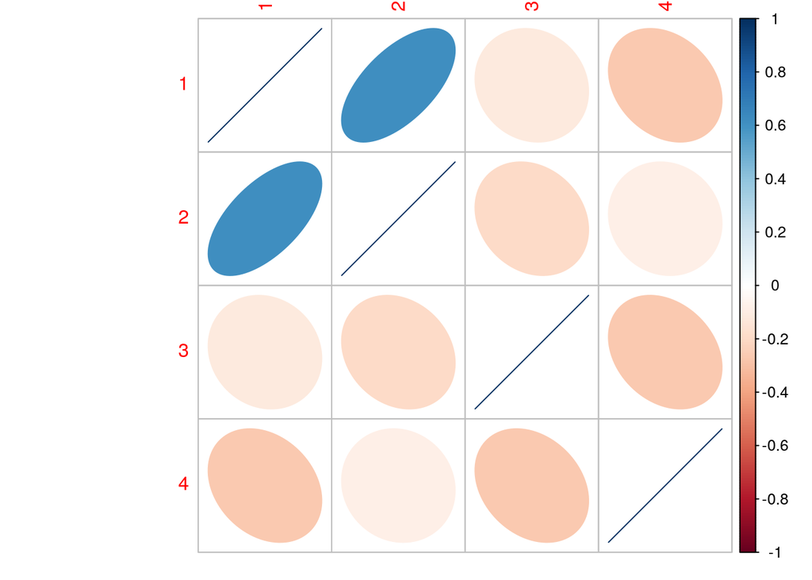

Ahora calcularemos las correlaciones canonicas construyendo la matriz A y calculando los valores propios

```r
R11 <- R[1:2, 1:2]
R12 <- R[1:2, 3:4]
R21 <- R[3:4, 1:2]
R22 <- R[3:4, 3:4]

(A <- solve(R11) %*% R12 %*% solve(R22) %*% R21)
```

```
##               [,1]       [,2]
## [1,]  0.1068048090 0.04756232
## [2,] -0.0002003833 0.02914188
```

```r
eigen(A)
```

```
## eigen() decomposition
## $values
## [1] 0.10668190 0.02926479
##
## $vectors
##              [,1]       [,2]
## [1,]  0.999996661 -0.5228640
## [2,] -0.002584248  0.8524161
```

```r
(B <- solve(R22) %*% R21 %*% solve(R11) %*% R12)
```

```
##            [,1]       [,2]
## [1,] 0.04504612 0.03795943
## [2,] 0.02562458 0.09090056
```

```r
eigen(B)
```

```
## eigen() decomposition
## $values
## [1] 0.10668190 0.02926479
##
## $vectors
##            [,1]       [,2]
## [1,] -0.5243952 -0.9233797
## [2,] -0.8514750  0.3838878
```

Notamos que la primer variable canónica le da más peso a los homicidios no primarios y la segunda variable le da mayor importancia a la probabilidad de castigo.Consideramos que las variables representan índices sobre la composición de los homicidios así como de las características de la acción punitiva. Además, la segunda variable canónica tiene signos negativos pues el segundo grupo de variables se correlacionan de forma negativa con el primer grupo. La correlación canónica es relativamente pequeña.

## Problema 7

Primero cargaremos los datos

```r
data <- read.csv("./bank-full.csv", header=T, sep=";")
```

Y obtenemos un primer resumen de los datos

```
## 'data.frame':    45211 obs. of  17 variables:
##  $ age      : int  58 44 33 47 33 35 28 42 58 43 ...
##  $ job      : Factor w/ 12 levels "admin.","blue-collar",..: 5 10 3 2 12 5 5 3 6 10 ...
##  $ marital  : Factor w/ 3 levels "divorced","married",..: 2 3 2 2 3 2 3 1 2 3 ...
##  $ education: Factor w/ 4 levels "primary","secondary",..: 3 2 2 4 4 3 3 3 1 2 ...
##  $ default  : Factor w/ 2 levels "no","yes": 1 1 1 1 1 1 1 2 1 1 ...
##  $ balance  : int  2143 29 2 1506 1 231 447 2 121 593 ...
##  $ housing  : Factor w/ 2 levels "no","yes": 2 2 2 2 1 2 2 2 2 2 ...
##  $ loan     : Factor w/ 2 levels "no","yes": 1 1 2 1 1 1 2 1 1 1 ...
##  $ contact  : Factor w/ 3 levels "cellular","telephone",..: 3 3 3 3 3 3 3 3 3 3 ...
##  $ day      : int  5 5 5 5 5 5 5 5 5 5 ...
##  $ month    : Factor w/ 12 levels "apr","aug","dec",..: 9 9 9 9 9 9 9 9 9 9 ...
##  $ duration : int  261 151 76 92 198 139 217 380 50 55 ...
##  $ campaign : int  1 1 1 1 1 1 1 1 1 1 ...
##  $ pdays    : int  -1 -1 -1 -1 -1 -1 -1 -1 -1 -1 ...
##  $ previous : int  0 0 0 0 0 0 0 0 0 0 ...
##  $ poutcome : Factor w/ 4 levels "failure","other",..: 4 4 4 4 4 4 4 4 4 4 ...
##  $ y        : Factor w/ 2 levels "no","yes": 1 1 1 1 1 1 1 1 1 1 ...
```

Nuestra primera idea fue tranformar las variables de tipo factor a indicadores y codificar las variables binarias (con valores “yes” o “no”) con ceros y unos. Despues de probar con cada una de las variables categóricas (job, marital, education, contact, poutcom) nos encontramos con el problema de que al intentar calcular las correlaciones canónicas , teníamos matrices numericamente singulares. Inclusive invocando la funcion stats::concor, la ejecución nos regresaba una dirección canónica con coeficientes faltantes.

Para poder avanzar tuvimos que dejar de lado las variables categoricas y realizar el analisis con las variables restantes.Así, trabajamos con los siguientes datos transformados.

```
## 'data.frame':    45211 obs. of  11 variables:
##  $ age     : int  58 44 33 47 33 35 28 42 58 43 ...
##  $ balance : int  2143 29 2 1506 1 231 447 2 121 593 ...
##  $ day     : int  5 5 5 5 5 5 5 5 5 5 ...
##  $ duration: int  261 151 76 92 198 139 217 380 50 55 ...
##  $ campaign: int  1 1 1 1 1 1 1 1 1 1 ...
##  $ pdays   : int  -1 -1 -1 -1 -1 -1 -1 -1 -1 -1 ...
##  $ previous: int  0 0 0 0 0 0 0 0 0 0 ...
##  $ default : num  0 0 0 0 0 0 0 1 0 0 ...
##  $ housing : num  1 1 1 1 0 1 1 1 1 1 ...
##  $ loan    : num  0 0 1 0 0 0 1 0 0 0 ...
##  $ y       : num  0 0 0 0 0 0 0 0 0 0 ...
```

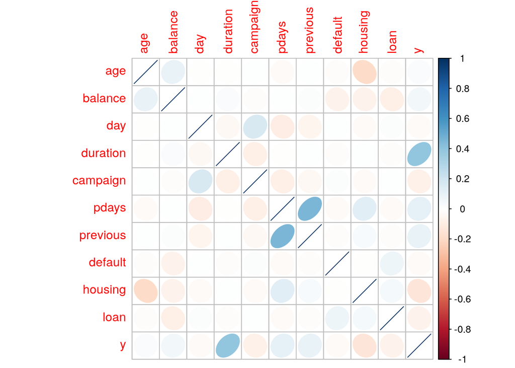

Ahora que tenemos una representación más amigable de los datos, consideramos que para atacar el problema de clasificación procederemos a realizar el análisis de correlación canonica tomando a “y” como uno de los grupos y las demas variables en el otro grupo. Esto se realiza con la intención de utilizar las variables canónicas como sustitutas que permitan representar la relación entre ambos grupos de variables de forma simplificada.

```
## $cor
## [1] 0.4178867
##
## $xcoef
##                   [,1]          [,2]          [,3]          [,4]
## age       2.630110e-06 -9.095025e-05  3.088164e-05 -3.650389e-04
## balance  -9.592031e-08  1.541749e-06 -2.616722e-09 -1.148303e-07
## day       4.536952e-06  4.887947e-07  5.648640e-04  2.096993e-05
## duration -1.606658e-05 -1.730954e-06  9.709221e-07  4.839347e-06
## campaign  1.089705e-04  1.174008e-05 -6.585215e-06  9.113006e-05
## pdays    -9.950745e-06 -1.072057e-06  6.013353e-07 -8.321628e-06
## previous -2.439593e-04 -2.628328e-05  1.474275e-05 -2.040187e-04
## default   7.405003e-04  7.977880e-05 -4.474931e-05  6.192670e-04
## housing   3.239948e-03  3.490602e-04 -1.957939e-04  2.709510e-03
## loan      1.468681e-03  1.582303e-04 -8.875410e-05  1.228231e-03
##                   [,5]          [,6]          [,7]          [,8]
## age       3.174004e-05 -8.367042e-05 -5.223470e-05 -1.623397e-05
## balance   3.008394e-08 -2.893814e-08 -3.490523e-08 -1.031576e-07
## day      -9.243516e-05  4.723459e-05  7.367421e-06  2.788807e-06
## duration  2.751775e-06 -3.259034e-06 -1.758131e-06 -5.331369e-07
## campaign  1.535108e-03  1.398898e-04 -4.671154e-06  2.099044e-05
## pdays     7.911731e-07  4.518470e-05 -2.505959e-05 -1.492407e-06
## previous  1.939694e-05 -5.247210e-05  2.267336e-03 -1.527486e-05
## default  -5.887638e-05  1.592709e-04  7.900994e-05 -3.543259e-02
## housing  -2.576048e-04  6.968658e-04  3.456961e-04  7.962109e-05
## loan     -1.167732e-04  3.158919e-04  1.567054e-04  3.609254e-05
##                   [,9]         [,10]
## age      -2.215157e-04  4.741932e-05
## balance  -1.135426e-07  1.294338e-07
## day      -8.329595e-06 -5.590071e-06
## duration -5.056417e-06  1.907111e-06
## campaign  1.968683e-05 -1.811781e-05
## pdays     2.945944e-06  2.256756e-06
## previous -1.218679e-04  2.199496e-05
## default  -8.652628e-05 -2.621963e-03
## housing  -8.687498e-03 -7.292321e-04
## loan      4.693876e-04  1.275669e-02
##
## $ycoef
##             [,1]
## [1,] -0.01375033
##
## $xcenter
##          age      balance          day     duration     campaign
## 4.093621e+01 1.362272e+03 1.580642e+01 2.581631e+02 2.763841e+00
##        pdays     previous      default      housing         loan
## 4.019783e+01 5.803234e-01 1.802659e-02 5.558382e-01 1.602265e-01
##
## $ycenter
## [1] 0
```

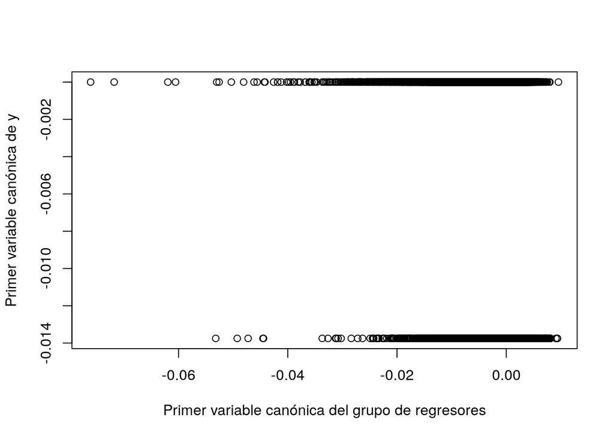

Las variables canónicas pueden ser utilizadas en un modélo posterior que defina un nivel de corte para la clasificación dentro de las personas que compran o no el servicio